# BCB420 Assignment 1 (Kevin Lu)

I’ll be using a dataset studying the effect of SARS-CoV-2 spike proteins on human lung cells (GSE185657). COVID-19 continues to be the topic on everybody’s minds after two years, so I thought I would analyze a dataset related to the virus causing it.

## 1. Download from GEO.

```r
library(GEOmetadb)
library(GEOquery)
```

Download the metadata GEO series, or load from disk if already downloaded.

```r
if (!file.exists("GSE185657.rds")) {
  gse <- getGEO("GSE185657")
  saveRDS("GSE185657.rds")
} else {
  gse <- readRDS("GSE185657.rds")
}
```

There are 24 samples in this series.

```r
length(GSMList(gse))
```

```
## [1] 24
```

The supplementary tarball for this dataset contains the raw counts, distributed across one file for each sample. We can construct the counts matrix since all files have the same length and the same Ensembl gene IDs in the same order.

```r
if (!file.exists("GSE185657_RAW.tar")) {
  files <- getGEOSuppFiles("GSE185657", makeDirectory=FALSE)
  target <- rownames(files[1])
} else{
  target <- "./GSE185657_RAW.tar"
}
contents <- untar(target, list=TRUE)
contents
```

```
##  [1] "GSM5621226_A_C1.txt.gz"  "GSM5621227_A_C2.txt.gz"
##  [3] "GSM5621228_A_C3.txt.gz"  "GSM5621229_A_C4.txt.gz"
##  [5] "GSM5621230_A_C5.txt.gz"  "GSM5621231_A_C6.txt.gz"
##  [7] "GSM5621232_A_Sp1.txt.gz" "GSM5621233_A_Sp2.txt.gz"
##  [9] "GSM5621234_A_Sp3.txt.gz" "GSM5621235_A_Sp4.txt.gz"
## [11] "GSM5621236_A_Sp5.txt.gz" "GSM5621237_A_Sp6.txt.gz"
## [13] "GSM5621238_B_C1.txt.gz"  "GSM5621239_B_C2.txt.gz"
## [15] "GSM5621240_B_C3.txt.gz"  "GSM5621241_B_C4.txt.gz"
## [17] "GSM5621242_B_C5.txt.gz"  "GSM5621243_B_C6.txt.gz"
## [19] "GSM5621244_B_Sp1.txt.gz" "GSM5621245_B_Sp2.txt.gz"
## [21] "GSM5621246_B_Sp3.txt.gz" "GSM5621247_B_Sp4.txt.gz"
## [23] "GSM5621248_B_Sp5.txt.gz" "GSM5621249_B_Sp6.txt.gz"
```

For some reason, instead of a compressed tarball, the authors compressed each *individual* file and then combined them into one archive. Extract each sample.

```r
# Remove all extracted files to reperform the extraction and decompression
if (!file.exists("GSM5621226_A_C1.txt")) {
  untar(target)
  lapply(contents, gunzip)
}
```

Finally, construct the counts matrix.

```r
targets <- gsub(".gz$", "", contents)
raw_list <- lapply(targets, read.delim)
genes <- raw_list[[1]]$Ensembl_gene_ID
samples <- sapply(raw_list, function (sample) colnames(sample)[2])
counts <- sapply(raw_list, function(sample) sample[[2]])
rownames(counts) <- genes
colnames(counts) <- samples
```

## 2. Assess

Here are some details regarding the conditions of the experiment and overview statistics on the data.

```r
Meta(gse)$title
```

```
## [1] "Differential effect of SARS-CoV-2 spike glycoprotein 1 on human bronchial and alveolar lung mucosa models: Implications on pathogenicity."
```

```r
Meta(gse)$overall_design
```

```
## [1] "Human bronchial and alveolar lung mucosa models cultured at air-liquid interface were treated with SARS-CoV-2 recombinant S1 protein or controls"
```

```r
Meta(gse)$last_update_date
```

```
## [1] "Dec 29 2021"
```

```r
Meta(gse)$summary
```

```
## [1] "The SARS-CoV-2 spike protein mediates attachment of the virus to host cell receptor and fusion between the virus and cell membrane. The S1 subunit of the spike glycoprotein (S1 protein) contains the angiotensin converting enzyme 2 (ACE2) receptor binding domain. The SARS-CoV-2 variants of co…
```

Confirm the prior assertions regarding the structure of the raw files.

```r
all(sapply(raw_list, function(sample) all.equal(genes, sample$Ensembl_gene_ID)))
```

```
## [1] TRUE
```

```r
length(unique(genes)) == length(genes)
```

```
## [1] TRUE
```

45368 genes were measured across 24 samples. According to the authors, this is an RNA-Seq dataset sequenced with Illumina NextSeq 500. The recorded values are CPM values, mapped to the GRCh38 genome assembly.

```r
dim(counts)
```

```
## [1] 45368    24
```

```r
knitr::kable(head(counts), format="html")
```

|  | A_C1 | A_C2 | A_C3 | A_C4 | A_C5 | A_C6 | A_Sp1 | A_Sp2 | A_Sp3 | A_Sp4 | A_Sp5 | A_Sp6 | B_C1 | B_C2 | B_C3 | B_C4 | B_C5 | B_C6 | B_Sp1 | B_Sp2 | B_Sp3 | B_Sp4 | B_Sp5 | B_Sp6 |
| --- | --- | --- | --- | --- | --- | --- | --- | --- | --- | --- | --- | --- | --- | --- | --- | --- | --- | --- | --- | --- | --- | --- | --- | --- |
| ENSG00000278878 | 1 | 0 | 2 | 2 | 2 | 2 | 4 | 2 | 3 | 1 | 2 | 1 | 0 | 0 | 1 | 0 | 0 | 1 | 0 | 1 | 10 | 5 | 7 | 8 |
| ENSG00000104313 | 0 | 1 | 0 | 0 | 0 | 0 | 1 | 0 | 0 | 0 | 1 | 0 | 0 | 1 | 0 | 0 | 0 | 0 | 3 | 1 | 0 | 1 | 6 | 4 |
| ENSG00000246859 | 1 | 2 | 2 | 2 | 0 | 1 | 7 | 0 | 1 | 0 | 1 | 1 | 0 | 1 | 0 | 1 | 1 | 2 | 7 | 1 | 3 | 1 | 7 | 11 |
| ENSG00000107159 | 3 | 4 | 2 | 7 | 5 | 5 | 4 | 5 | 3 | 0 | 9 | 3 | 0 | 1 | 1 | 1 | 0 | 0 | 1 | 1 | 11 | 1 | 3 | 3 |
| ENSG00000198453 | 5 | 4 | 6 | 2 | 2 | 6 | 5 | 3 | 9 | 2 | 2 | 5 | 1 | 1 | 1 | 0 | 0 | 1 | 6 | 2 | 2 | 3 | 3 | 7 |
| ENSG00000221817 | 3 | 6 | 1 | 3 | 3 | 1 | 2 | 4 | 6 | 1 | 2 | 1 | 1 | 0 | 0 | 0 | 2 | 0 | 3 | 2 | 1 | 4 | 4 | 0 |

## 3. Map to HUGO gene symbols

Conveniently, we already have a unique list of GRCh38 Ensembl gene IDs for this dataset. We can get the gene symbols with `biomaRt`, which might be more helpful for human interpretation.

```r
GRCh38 <- biomaRt::useEnsembl("genes", "hsapiens_gene_ensembl")
ensg2hgnc <- biomaRt::getBM(c("ensembl_gene_id", "hgnc_symbol"), mart=GRCh38)
```

There isn’t necessarily a gene symbol for a particular Ensembl ID.

```r
gene_symbols <- ensg2hgnc$hgnc_symbol[match(genes, ensg2hgnc$ensembl_gene_id)]
any(gene_symbols == "")
```

```
## [1] TRUE
```

```r
any(is.na(gene_symbols))
```

```
## [1] TRUE
```

## 4. Clean as necessary

From lecture 4, according to the `edgeR` protocol, it is recommended to remove features with insufficient reads. In this experiment, there are six replicates per group (alveolar and bronchial cells with and without spike protein).

How many genes would be kept if the ones without at least one read per million in six samples were removed?

```r
sum(rowSums(counts > 1) >= 6)
```

```
## [1] 14703
```

About two-thirds of genes are dropped. However, some Ensembl IDs still do not have corresponding symbols.

```r
filtered_counts <- counts[rowSums(counts > 1) >= 6, ]
filtered_symbols <- ensg2hgnc$hgnc_symbol[match(rownames(filtered_counts), ensg2hgnc$ensembl_gene_id)]
any(filtered_symbols == "")
```

```
## [1] TRUE
```

```r
any(is.na(filtered_symbols))
```

```
## [1] TRUE
```

## 5. Apply normalization

Per lecture 4, let’s get box plots of these CPMs pre-normalization.

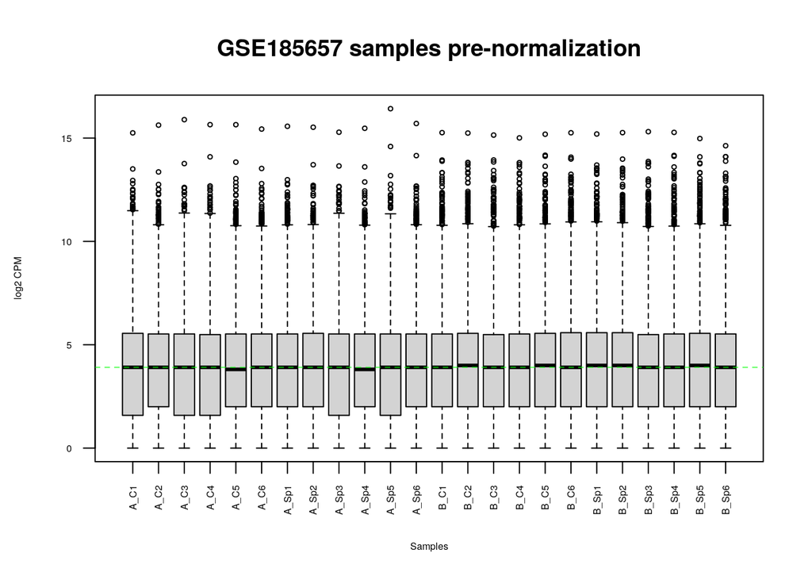

```r
data2plot <- log2(filtered_counts)
boxplot(data2plot, xlab = "Samples", ylab = "log2 CPM",
        las = 2, cex = 0.5, cex.lab = 0.5,
        cex.axis = 0.5, main = "GSE185657 samples pre-normalization")
#draw the median on each box plot
abline(h = median(apply(data2plot, 2, median)), col = "green", lwd = 0.6, lty = "dashed")
```

Even after cleaning, some samples still have 0 CPM for a feature, which results in -Inf logarithms for the plot.

As for density, again following the lecture slides:

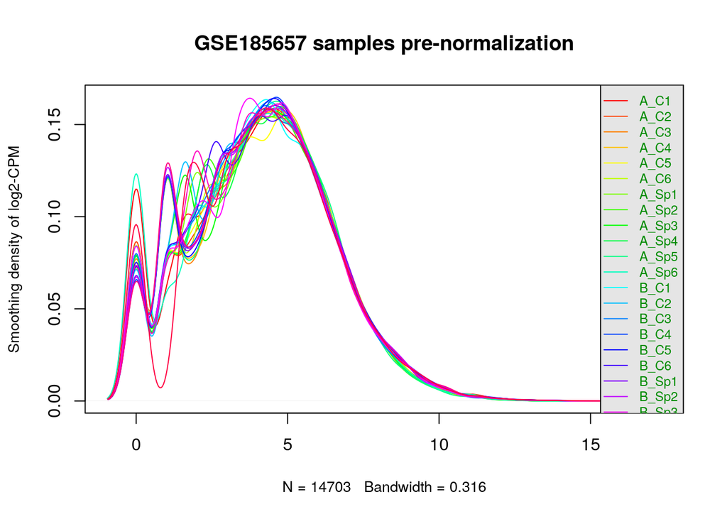

```r
counts_density <- apply(log2(filtered_counts), 2, density)
#calculate the limits across all the samples
xlim <- 0; ylim <- 0
for (i in 1:length(counts_density)) {
  xlim <- range(c(xlim, counts_density[[i]]$x));
  ylim <- range(c(ylim, counts_density[[i]]$y))
}
cols <- rainbow(length(counts_density))
ltys <- rep(1, length(counts_density))
#plot the first density plot to initialize the plot
plot(counts_density[[1]], xlim=xlim, ylim=ylim, type="n",
     ylab="Smoothing density of log2-CPM",
     main="GSE185657 samples pre-normalization", cex.lab = 0.85)
#plot each line
for (i in 1:length(counts_density))
  lines(counts_density[[i]], col=cols[i], lty=ltys[i])
#create legend
legend("topright", colnames(data2plot),
       col=cols, lty=ltys, cex=0.75,
       border ="blue",  text.col = "green4",
       merge = TRUE, bg = "gray90")
```

This looks kind of funny.

Since we are already using `edgeR` for this RNA-Seq dataset, let’s apply TMM normalization to the filtered CPMs.

```r
groups <- gsub("\\d", "", colnames(filtered_counts))
d <- edgeR::DGEList(filtered_counts, group = groups)
d <- edgeR::calcNormFactors(d)
normalized_counts <- edgeR::cpm(d)
```

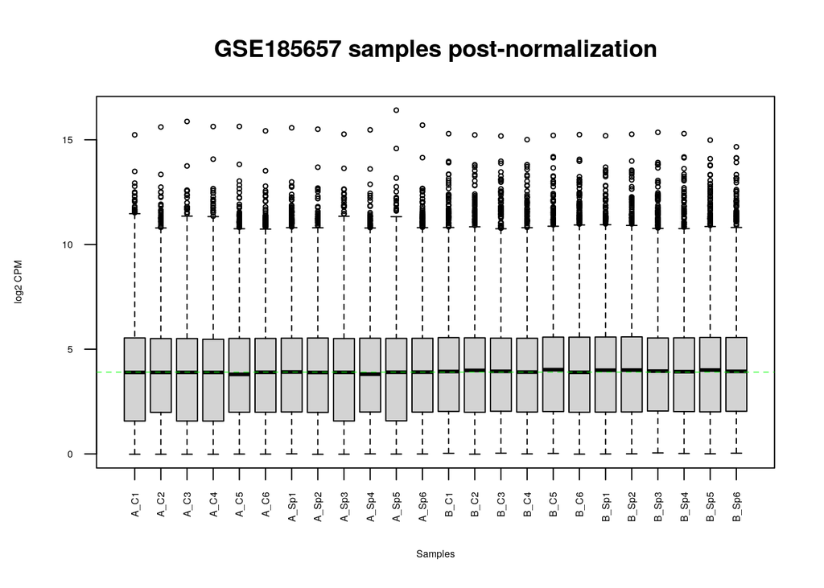

```r
data2plot <- log2(normalized_counts)
boxplot(data2plot, xlab = "Samples", ylab = "log2 CPM",
        las = 2, cex = 0.5, cex.lab = 0.5,
        cex.axis = 0.5, main = "GSE185657 samples post-normalization")
#draw the median on each box plot
abline(h = median(apply(data2plot, 2, median)), col = "green", lwd = 0.6, lty = "dashed")
```

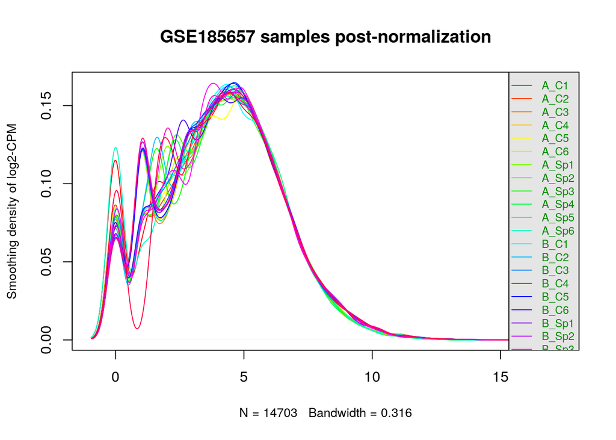

```r
counts_density <- apply(log2(normalized_counts), 2, density)
#calculate the limits across all the samples
xlim <- 0; ylim <- 0
for (i in 1:length(counts_density)) {
  xlim <- range(c(xlim, counts_density[[i]]$x));
  ylim <- range(c(ylim, counts_density[[i]]$y))
}
cols <- rainbow(length(counts_density))
ltys <- rep(1, length(counts_density))
#plot the first density plot to initialize the plot
plot(counts_density[[1]], xlim=xlim, ylim=ylim, type="n",
     ylab="Smoothing density of log2-CPM",
     main="GSE185657 samples post-normalization", cex.lab = 0.85)
#plot each line
for (i in 1:length(counts_density))
  lines(counts_density[[i]], col=cols[i], lty=ltys[i])
#create legend
legend("topright", colnames(data2plot),
       col=cols, lty=ltys, cex=0.75,
       border ="blue",  text.col = "green4",
       merge = TRUE, bg = "gray90")
```

## 6. Interpretation

Most of these were implicitly addressed above.

**What are the control and test conditions of the dataset?** **Why is the dataset of interest to you?** **Were there expression values that were not unique for specific genes? How did you handle these?** **Were there expression values that could not be mapped to current HUGO symbols?** **How many outliers were removed?** **How did you handle replicates?** **What is the final coverage of your dataset?**

## 7. Citations

Rahman M, Irmler M, Keshavan S, Introna M et al. Differential Effect of SARS-CoV-2 Spike Glycoprotein 1 on Human Bronchial and Alveolar Lung Mucosa Models: Implications for Pathogenicity. Viruses 2021 Dec 17;13(12). PMID: [34960806](https://www.ncbi.nlm.nih.gov/pmc/articles/PMC8708014/)

```r
citation("GEOmetadb")
```

```
##
## A BibTeX entry for LaTeX users is
##
##   @Article{,
##     author = {Yuelin Zhu and Sean Davis and Robert Stephens and Paul S. Meltzer and Yidong Chen},
##     title = {GEOmetadb: powerful alternative search engine for the Gene Expression Omnibus.},
##     journal = {Bioinformatics (Oxford, England)},
##     year = {2008},
##     month = {Dec},
##     day = {01},
##     volume = {24},
##     number = {23},
##     pages = {2798--2800},
##     abstract = {The NCBI Gene Expression Omnibus (GEO) represents the largest public repository of microarray data. However, finding data in GEO can be challenging. We have developed GEOmetadb in an attempt to make querying the GEO metadata both easier and more powerful. All GEO metadata records …
##     issn = {1367-4811},
##     doi = {10.1093/bioinformatics/btn520},
##     url = {http://www.ncbi.nlm.nih.gov/pubmed/18842599},
##     language = {eng},
##   }
```

```r
citation("GEOquery")
```

```
##
## A BibTeX entry for LaTeX users is
##
##   @Article{,
##     author = {Sean Davis and Paul Meltzer},
##     title = {GEOquery: a bridge between the Gene Expression Omnibus (GEO) and BioConductor},
##     journal = {Bioinformatics},
##     year = {2007},
##     volume = {14},
##     pages = {1846--1847},
##   }
```

```r
citation("biomaRt")
```

```
##
##
##   Mapping identifiers for the integration of genomic datasets with the
##   R/Bioconductor package biomaRt. Steffen Durinck, Paul T. Spellman,
##   Ewan Birney and Wolfgang Huber, Nature Protocols 4, 1184-1191 (2009).
##
##   BioMart and Bioconductor: a powerful link between biological
##   databases and microarray data analysis. Steffen Durinck, Yves Moreau,
##   Arek Kasprzyk, Sean Davis, Bart De Moor, Alvis Brazma and Wolfgang
##   Huber, Bioinformatics 21, 3439-3440 (2005).
##
## To see these entries in BibTeX format, use 'print(<citation>,
## bibtex=TRUE)', 'toBibtex(.)', or set
## 'options(citation.bibtex.max=999)'.
```

```r
citation("edgeR")
```

```
##
## See Section 1.2 in the User's Guide for more detail about how to cite
## the different edgeR pipelines.
##
##   Robinson MD, McCarthy DJ and Smyth GK (2010). edgeR: a Bioconductor
##   package for differential expression analysis of digital gene
##   expression data. Bioinformatics 26, 139-140
##
##   McCarthy DJ, Chen Y and Smyth GK (2012). Differential expression
##   analysis of multifactor RNA-Seq experiments with respect to
##   biological variation. Nucleic Acids Research 40, 4288-4297
##
##   Chen Y, Lun ATL, Smyth GK (2016). From reads to genes to pathways:
##   differential expression analysis of RNA-Seq experiments using
##   Rsubread and the edgeR quasi-likelihood pipeline. F1000Research 5,
##   1438
##
## To see these entries in BibTeX format, use 'print(<citation>,
## bibtex=TRUE)', 'toBibtex(.)', or set
## 'options(citation.bibtex.max=999)'.
```